# Modeling and prediction for movies

## Setup

### Load packages

```r
library(ggplot2)
library(dplyr)
library(statsr)
library(GGally)
```

### Load data

```r
load("movies.Rdata")
```

## Part 1: Data

**generalizability:**

The `movies` dataset includes information from Rotten Tomatoes and IMDB for a random sample of movies. There are 651 observations in the data, so the sample size is not too small. It’s reasonable to assume that such a random sample is representative of the movies population, so the conclusions based on this dataset can be generalized as well.

**causality:**

The `movies` dataset includes only observational data, no experiment has been conducted. Therefore, we can only find association relationship between variables, but no causality can be inferred from the data.

## Part 2: Research question

In context of this particular dataset, my boss is interested in learning what attributes make a movie popular. Therefore, I will stick to this question and try to find out the most significant attributes that make a movie popular. Besides, she is also interested in learning something new about movies. That said, if I could find a model that accurately predicts the movies popularity, I can recommend new movies to her. If she really loves the movies I recommend, maybe I can get a promotion :)

Concretely, I’m trying to find an optimal parsimonius linear regression model using backward-elinimation method based on p-value.

For the response variable, I will use `imdb_num_votes` which stands for the number of votes on IMDB. IMDB is one of the largest movies database with millions of users, so the number of votes on IMDB is very indicative of a movie’s popularity. In general, the higher the number of votes, the more popular a movie is. However, this is not always the case. Here I will just focus on the *popularity* rather than the *quality* of the movie. There are also some other variables related to “rating” such as `audience_score` and `critics_score`, but these variables might not be a good measure of popularity for two reasons:

1. The score of a movie measures the quality of movie and whether or not people who have watched the movie are satisfied with it. Some movies are bizarre in its style and do not meet the tastes of the majority, but they might be in fact of good quality so the audience who are interested in such a style tend to rate them high, while those who are not interested are not likely to watch it. This kind of movie can be a masterpiece with very few people knowing about it.
2. Some movies might be very popular among people who have not even watched it. Such cases are not rare where the studio has spent millions of dollars in advertising of the movie, or the main actors are extremely famous. Regardless how famous the actors and directors are, the story of the movie might not be as good.

For the explanatory variables, below is a list of candidates that I think are the most relevant:

| variable | description |
| --- | --- |
| `imdb_rating` | Rating on IMDB |
| `audience_score` | Audience score on Rotten Tomatoes |
| `critics_score` | Critics score on Rotten Tomatoes |
| `runtime` | Runtime of movie (in minutes) |
| `thtr_rel_year` | Year the movie is released in theaters |
| `best_dir_win` | Whether or not the director of the movie ever won an Oscar (no, yes) |
| `best_actor_win` | Whether or not one of the main actors in the movie ever won an Oscar (no, yes) |
| `best_actress_win` | Whether or not one of the main actresses in the movie ever won an Oscar (no, yes) |

## Part 3: Exploratory data analysis

First, select the variables of interest and simply remove missing value.

```r
movies %>%
  select(imdb_num_votes, imdb_rating, audience_score, critics_score, runtime,
         thtr_rel_year, best_dir_win, best_actor_win, best_actress_win) %>%
  filter(!is.na(imdb_num_votes) & !is.na(imdb_rating) & !is.na(audience_score) &
         !is.na(critics_score) & !is.na(runtime) & !is.na(thtr_rel_year) &
         !is.na(best_dir_win) & !is.na(best_actor_win) & !is.na(best_actress_win)
        ) -> movies
glimpse(movies)
```

```
## Observations: 650
## Variables: 9
## $ imdb_num_votes   <int> 899, 12285, 22381, 35096, 2386, 333, 5016, 22...
## $ imdb_rating      <dbl> 5.5, 7.3, 7.6, 7.2, 5.1, 7.8, 7.2, 5.5, 7.5, ...
## $ audience_score   <dbl> 73, 81, 91, 76, 27, 86, 76, 47, 89, 66, 75, 4...
## $ critics_score    <dbl> 45, 96, 91, 80, 33, 91, 57, 17, 90, 83, 89, 6...
## $ runtime          <dbl> 80, 101, 84, 139, 90, 78, 142, 93, 88, 119, 1...
## $ thtr_rel_year    <dbl> 2013, 2001, 1996, 1993, 2004, 2009, 1986, 199...
## $ best_dir_win     <fct> no, no, no, yes, no, no, no, no, no, no, no, ...
## $ best_actor_win   <fct> no, no, no, yes, no, no, no, yes, no, no, yes...
## $ best_actress_win <fct> no, no, no, no, no, no, no, no, no, no, no, n...
```

Since the dataset does not have too many missing values, we lost only one observation after filtering.

In consideration of collinearity, let’s see the correlation between the numerical variables.

```r
numerical_vars = select(movies, imdb_rating, audience_score, critics_score, runtime, thtr_rel_year)
cor(numerical_vars)
```

```
##                imdb_rating audience_score critics_score    runtime
## imdb_rating     1.00000000     0.86490913     0.7647832  0.2682405
## audience_score  0.86490913     1.00000000     0.7041573  0.1809629
## critics_score   0.76478324     0.70415734     1.0000000  0.1724989
## runtime         0.26824048     0.18096290     0.1724989  1.0000000
## thtr_rel_year  -0.03135507    -0.05479688    -0.0819862 -0.1043767
##                thtr_rel_year
## imdb_rating      -0.03135507
## audience_score   -0.05479688
## critics_score    -0.08198620
## runtime          -0.10437672
## thtr_rel_year     1.00000000
```

From the correlation matrix, we can see that the correlation coefficients between `imdb_rating`, `audience_score` and `critics_score` are very high (0.70 ~ 0.86), so they are highly associated with each other, which also means that they are suffering from multicollinearity.

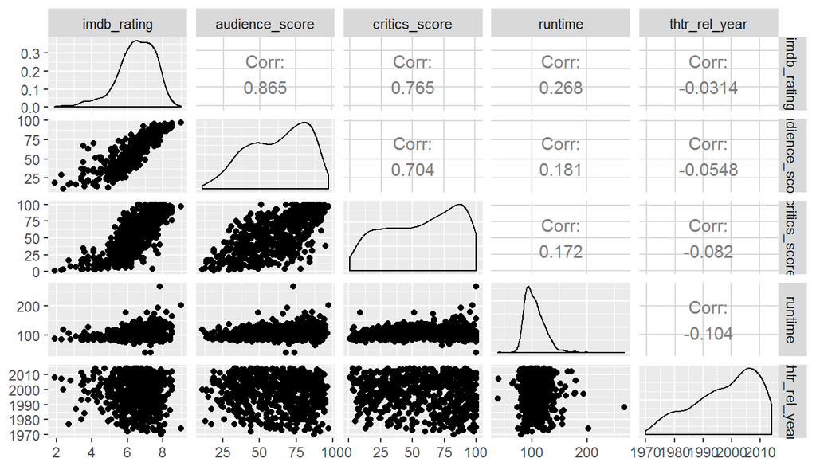

```r
ggpairs(numerical_vars)
```

The `ggpairs()` function gives us a summary of various plots between these variables:

**Scatterplot:**  
* There’s a clear trend that `imdb_rating`, `audience_score`, and `critics_score` are positively related.  
* It looks like ratings of movies have nothing to do with `runtime` and `thtr_rel_year`. These scores are not biased toward longer and more recent movies, so to speak.

**Correlations:**  
* The coefficients between ratings are consistent with our findings above.  
* The correlation between `runtime` and the ratings variables are from 0.17 to 0.26, so there could be a trend that the scores of longer movies are higher, but the relationship is weak.  
* The correlation between `thtr_rel_year` and the ratings variables are negative, so it looks like that old movies are rated higher, but this relationship is even weaker because the correlation is close to zero.

Next, let’s turn to see the correlation between categorical variables `best_dir_win`, `best_actor_win` and `best_actress_win`.

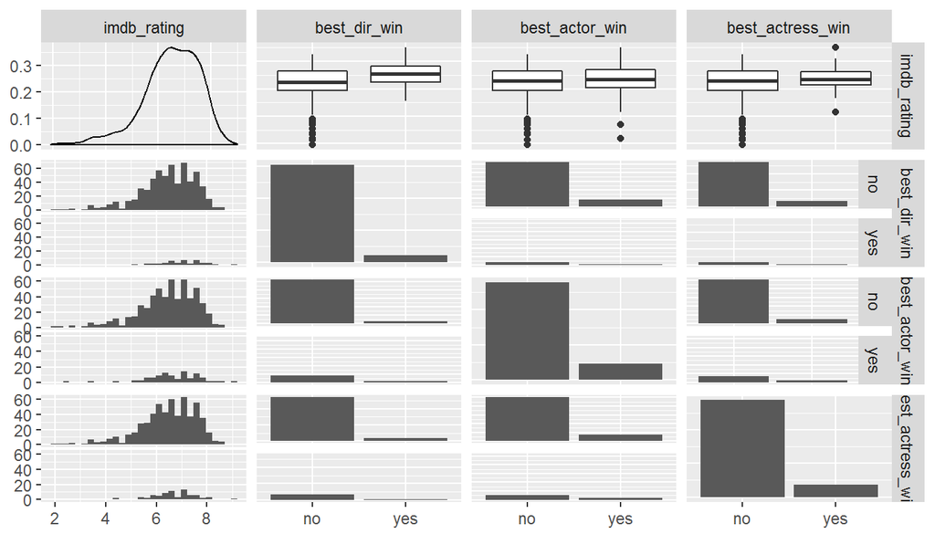

```r
movies %>%
  select(imdb_rating, best_dir_win, best_actor_win, best_actress_win) %>%
  ggpairs()
```

The `ggpairs()` function on categorical variables now gives us a set of different plots:

**Histograms:**  
* There are much more “no” than “yes” in terms of `best_dir_win`, `best_actor_win` and `best_actress_win`, so movies with very famous directors, actors or actresses are rare.

**Boxplot:**  
* In general, the medians of movies with very famous directors, actors or actresses tend to be higher.  
* Movies without a popular star have many outliers of very low ratings.

Now that we see `imdb_rating`, `audience_score` and `critics_score` are suffering from multicollinearity, it’s better to keep only one of them and remove the other two. Adding a second variable brings nothing new to the model since information included in them are overlapped, and we know that collinear variables can result in biased estimates of the regression parameters.

However, we don’t want to remove variables randomly. Even if they are correlated, information in these variables are not exactly the same. In order to include all information, I’m going to create a new variable which gives the average rating scores based on the 3 variables.

```r
movies %>%
  select(imdb_rating, audience_score, critics_score) %>%
  summary()
```

```
##   imdb_rating    audience_score  critics_score
##  Min.   :1.900   Min.   :11.00   Min.   :  1.00
##  1st Qu.:5.900   1st Qu.:46.00   1st Qu.: 33.00
##  Median :6.600   Median :65.00   Median : 61.00
##  Mean   :6.492   Mean   :62.35   Mean   : 57.65
##  3rd Qu.:7.300   3rd Qu.:80.00   3rd Qu.: 83.00
##  Max.   :9.000   Max.   :97.00   Max.   :100.00
```

From the summary statistics, it’s clear that the scores range from 0 to 100, while the rating is on a scale of 0~10. Before we take the average of them, first let’s multiply the `imdb_rating` by 10 so that all 3 variables are measured on the same scale.

```r
movies %>%
  mutate(imdb_rating = 10 * imdb_rating) -> movies
summary(movies$imdb_rating)
```

```
##    Min. 1st Qu.  Median    Mean 3rd Qu.    Max.
##   19.00   59.00   66.00   64.92   73.00   90.00
```

Next, we create the new variable `avg_score` as the explanatory variable.

```r
movies %>%
  mutate(avg_score = (imdb_rating + audience_score + critics_score) / 3) -> movies
```

Furthermore, we noticed that the response variable `imdb_num_votes` has a much higher order of magnitude compared to other variables. Therefore, such a linear regression model will give us very large coefficients. As our last step, let’s perform a log transformation on `imdb_num_votes`.

```r
movies %>%
  mutate(imdb_num_votes = log(imdb_num_votes)) -> movies
```

## Part 4: Modeling

Now let’s build up a full model using the list of explanatory variables candidates, and then apply the backward-elinimation methods based on p-value to find out our best model.

```r
m_full <- lm(imdb_num_votes ~ avg_score + runtime + thtr_rel_year +
                              best_dir_win + best_actor_win + best_actress_win,
             data = movies)
summary(m_full)
```

```
##
## Call:
## lm(formula = imdb_num_votes ~ avg_score + runtime + thtr_rel_year +
##     best_dir_win + best_actor_win + best_actress_win, data = movies)
##
## Residuals:
##     Min      1Q  Median      3Q     Max
## -5.8949 -1.0385  0.0456  1.1168  3.5463
##
## Coefficients:
##                       Estimate Std. Error t value Pr(>|t|)
## (Intercept)         -74.259970  11.016388  -6.741 3.51e-11 ***
## avg_score             0.008557   0.003361   2.546 0.011140 *
## runtime               0.020490   0.003379   6.064 2.26e-09 ***
## thtr_rel_year         0.040613   0.005495   7.392 4.53e-13 ***
## best_dir_winyes       0.906270   0.249701   3.629 0.000307 ***
## best_actor_winyes     0.333679   0.177444   1.880 0.060496 .
## best_actress_winyes   0.220311   0.195156   1.129 0.259363
## ---
## Signif. codes:  0 '***' 0.001 '**' 0.01 '*' 0.05 '.' 0.1 ' ' 1
##
## Residual standard error: 1.52 on 643 degrees of freedom
## Multiple R-squared:  0.1803, Adjusted R-squared:  0.1726
## F-statistic: 23.57 on 6 and 643 DF,  p-value: < 2.2e-16
```

The F-test yielding a p-value close to zero means that our model is not meaningless, at least one of the coefficients is non-zero. Since my boss is most interested in finding the most significant attributes that makes a movie popular, I will drop variables based on the p-value rather than adjusted R-square. `best_actress_win` has the highest p-value of 0.259, so we remove it first and refit the model.

```r
m1 <- lm(imdb_num_votes ~ avg_score + runtime + thtr_rel_year +
                          best_dir_win + best_actor_win,
         data = movies)
summary(m1)
```

```
##
## Call:
## lm(formula = imdb_num_votes ~ avg_score + runtime + thtr_rel_year +
##     best_dir_win + best_actor_win, data = movies)
##
## Residuals:
##     Min      1Q  Median      3Q     Max
## -6.0193 -1.0483  0.0425  1.1001  3.5192
##
## Coefficients:
##                     Estimate Std. Error t value Pr(>|t|)
## (Intercept)       -74.185379  11.018537  -6.733 3.69e-11 ***
## avg_score           0.008598   0.003362   2.557 0.010775 *
## runtime             0.021119   0.003333   6.336 4.44e-10 ***
## thtr_rel_year       0.040552   0.005495   7.379 4.93e-13 ***
## best_dir_winyes     0.914150   0.249656   3.662 0.000271 ***
## best_actor_winyes   0.350494   0.176856   1.982 0.047926 *
## ---
## Signif. codes:  0 '***' 0.001 '**' 0.01 '*' 0.05 '.' 0.1 ' ' 1
##
## Residual standard error: 1.521 on 644 degrees of freedom
## Multiple R-squared:  0.1786, Adjusted R-squared:  0.1723
## F-statistic: 28.01 on 5 and 644 DF,  p-value: < 2.2e-16
```

```r
m2 <- lm(imdb_num_votes ~ avg_score + runtime + thtr_rel_year + best_dir_win,
         data = movies)
summary(m2)
```

```
##
## Call:
## lm(formula = imdb_num_votes ~ avg_score + runtime + thtr_rel_year +
##     best_dir_win, data = movies)
##
## Residuals:
##     Min      1Q  Median      3Q     Max
## -6.3281 -1.0602  0.0196  1.1598  3.4627
##
## Coefficients:
##                   Estimate Std. Error t value Pr(>|t|)
## (Intercept)     -73.643669  11.040115  -6.671 5.49e-11 ***
## avg_score         0.008485   0.003369   2.518 0.012030 *
## runtime           0.022726   0.003240   7.014 5.88e-12 ***
## thtr_rel_year     0.040224   0.005505   7.306 8.14e-13 ***
## best_dir_winyes   0.933477   0.250031   3.733 0.000206 ***
## ---
## Signif. codes:  0 '***' 0.001 '**' 0.01 '*' 0.05 '.' 0.1 ' ' 1
##
## Residual standard error: 1.524 on 645 degrees of freedom
## Multiple R-squared:  0.1736, Adjusted R-squared:  0.1685
## F-statistic: 33.88 on 4 and 645 DF,  p-value: < 2.2e-16
```

Last but not least, let’s work on the diagnostics of the model.

**Linearity:**

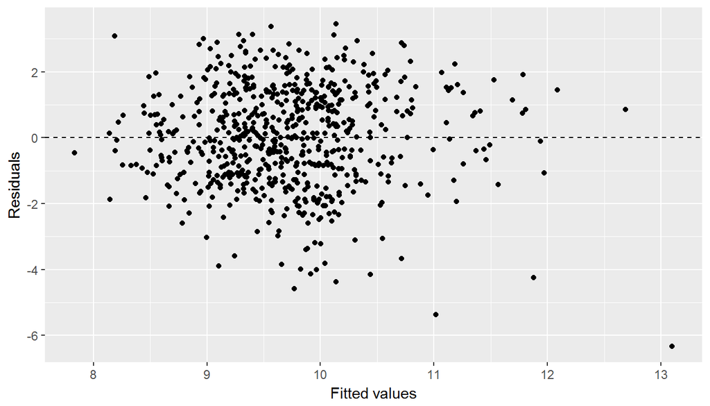

```r
ggplot(data = m2, aes(x = .fitted, y = .resid)) +
  geom_point() +
  geom_hline(yintercept = 0, linetype = "dashed") +
  xlab("Fitted values") +
  ylab("Residuals")
```

It looks like the residuals are randomly scattered around 0.

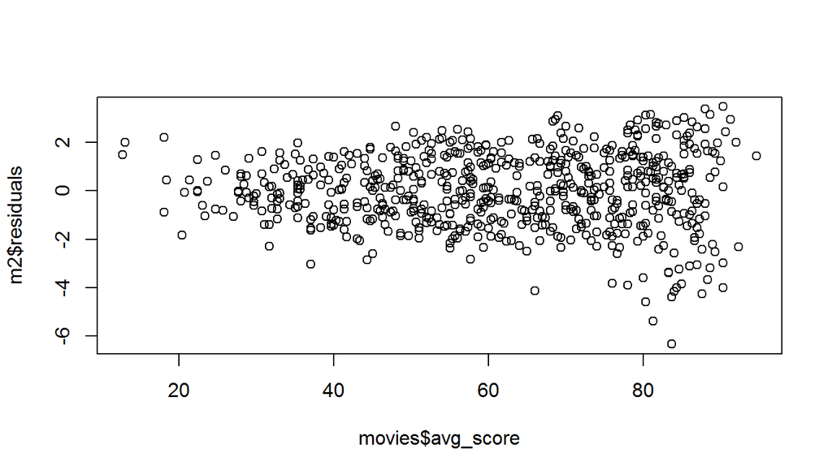

```r
plot(m2$residuals ~ movies$avg_score)
```

A scatterplot between `m2$residuals` and `movies$avg_score` confirms the point, that the model residuals are randomly distributed around zero. The plot also shows that we have more observations with higher `avg_score`.

**Nearly normal residuals:**

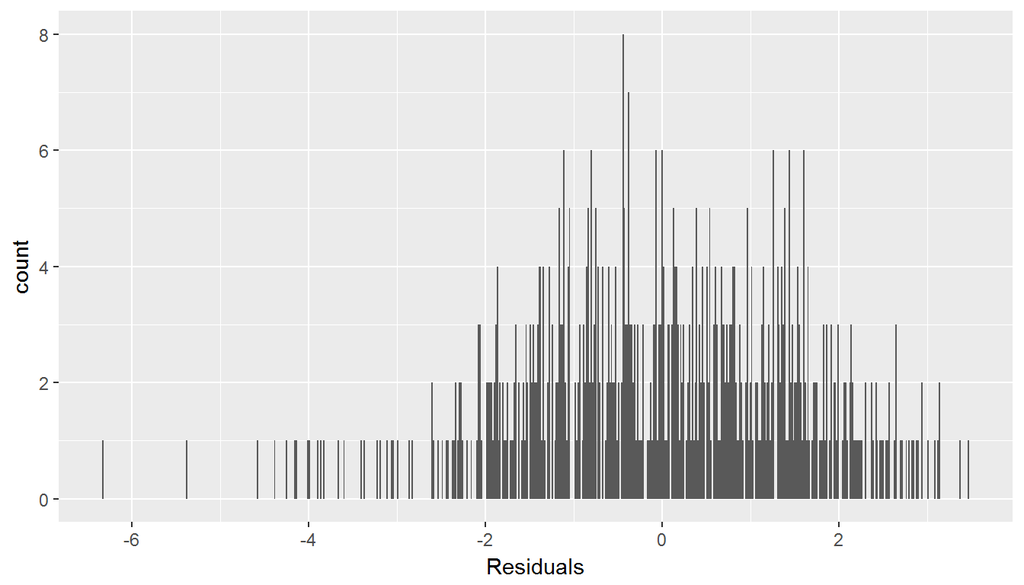

```r
ggplot(data = m2, aes(x = .resid)) +
  geom_histogram(bins = 600) +
  xlab("Residuals")
```

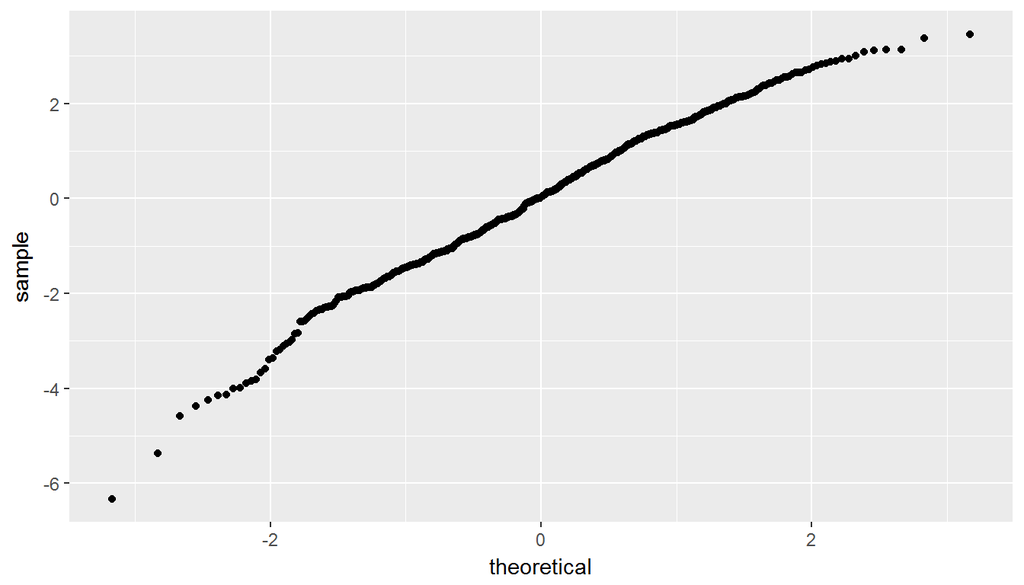

```r
ggplot(data = m2, aes(sample = .resid)) +
  stat_qq()
```

Both the histogram and normal probability plot suggest a nearly normal distribution of the residuals.

**Constant variability:**

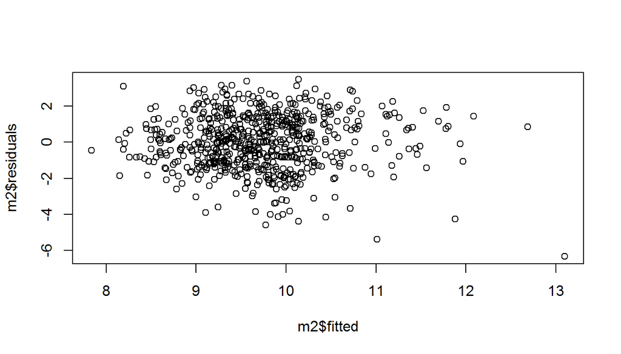

```r
plot(m2$residuals ~ m2$fitted)
```

We already see that the variance of residuals are roughly consistent across the sample.

**Independent residuals:**

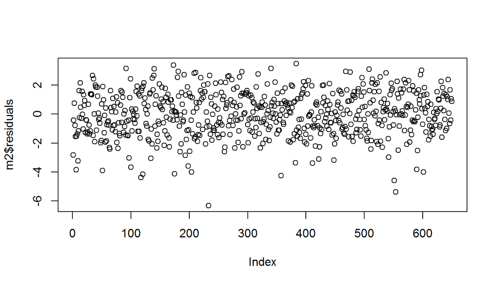

```r
plot(m2$residuals)
```

Finally, the residuals plot against observation indices shows that observations are independent, of course this is true because people don’t rate a movie based on other movies.

## Part 5: Prediction

In the prediction part, I will choose a very famous movie “La La Land” to test my model. Both the director and main actor and actress are nominated for the Oscar prize, and we can find related information on the IMDB website.

```r
la_la_land <- data.frame(avg_score = 81, runtime = 128, thtr_rel_year = 2016, best_dir_win = "yes")
predict(m2, la_la_land, interval = "prediction", level = 0.95)
```

```
##      fit      lwr      upr
## 1 11.977 8.938478 15.01551
```

```r
exp(predict(m2, la_la_land, interval = "prediction", level = 0.95))
```

```
##        fit      lwr     upr
## 1 159053.4 7619.591 3320124
```

Based on the result, we are 95% confident that the number of IMDB votes falls in the range of (7619, 3320124). It turns out, this range is too wide to be considered a good estimate.

## Part 6: Conclusion

```r
summary(m2)
```

```
##
## Call:
## lm(formula = imdb_num_votes ~ avg_score + runtime + thtr_rel_year +
##     best_dir_win, data = movies)
##
## Residuals:
##     Min      1Q  Median      3Q     Max
## -6.3281 -1.0602  0.0196  1.1598  3.4627
##
## Coefficients:
##                   Estimate Std. Error t value Pr(>|t|)
## (Intercept)     -73.643669  11.040115  -6.671 5.49e-11 ***
## avg_score         0.008485   0.003369   2.518 0.012030 *
## runtime           0.022726   0.003240   7.014 5.88e-12 ***
## thtr_rel_year     0.040224   0.005505   7.306 8.14e-13 ***
## best_dir_winyes   0.933477   0.250031   3.733 0.000206 ***
## ---
## Signif. codes:  0 '***' 0.001 '**' 0.01 '*' 0.05 '.' 0.1 ' ' 1
##
## Residual standard error: 1.524 on 645 degrees of freedom
## Multiple R-squared:  0.1736, Adjusted R-squared:  0.1685
## F-statistic: 33.88 on 4 and 645 DF,  p-value: < 2.2e-16
```

The model predicts the number of votes of “La la land” to be 159,053, while the true value on IMDB is 352,092 votes. The problem here is that the adjusted R-square is less than 20%, so the model can only explain 20% of the variability in the response variable.  
However, with all the data we have, we still find that the average rating of the movie, the length, as well as the year it was released are closely related to the popularity. The most significant attribute in our model is `thtr_rel_year`. This means that the more recent a movie was released, the more popular it tends to be. On the flip side, while the average rating score also has a p-value of 0.01, it is less significant.

I believe, that popularity may not be a good measure of the movie’s true value. Even if a movie is popular for now, one day it will finally disappear from audience’s memories. After all, it’s how popular a movie is among the current population, but the population is constantly changing over time. In the old times, not many people have a lot of chances to go to the theater and watch movies on a regular basis, but today we can all stay at home on weekends and enjoy movies at any time we like.